# Our R cheatsheet

Pietro Franceschi | pietro.franceschi@fmach.it

This page collects the few R ideas we will use over and over during the course: R Markdown, the pipe, tibbles, the core `dplyr` verbs, `purrr` for iterations and nested tables. It is not a full R tutorial, just the minimum to read (and write) the code of the course.

## Rmd

Everything you see in the course website has been created with R, relying on `.Rmd` (R Markdown) files. An Rmd file combines

1. text written in a simplified format (Markdown)
2. R chunks which can be executed independently

Rmd files can be “compiled” (knitted) into various formats (html, docx, pdf, slides) and are extremely handy to keep code, results and comments together. This is a big step towards reproducible analysis.

To compile a file from RStudio press the **Knit** button, or from the console run

```r
rmarkdown::render("Our_R_cheatsheet.Rmd")
```

## Pipes

In almost all my code I rely on *pipes* (`|>`). The pipe makes code easier to read when several functions are nested one inside the other.

```r
## consider for example
a <- 10
b <- sqrt(log(a + 2)) ## a trivial nested function: it has to be read from the inside out ...

## with the pipe I can write the same thing as a sequence of steps
b1 <- (a + 2) |>   ## take a + 2
  log() |>         ## take the log
  sqrt()           ## take the square root

identical(b, b1)
```

```
## [1] TRUE
```

You can imagine the pipe operator just like a pipe, which connects two functions passing the output of the first one as the **first argument** of the second one: `x |> f(y)` is the same as `f(x, y)`.

If the object coming from the pipe has to go to a different argument, use the placeholder `_`, which must be used with a named argument:

```r
mtcars |>
  lm(mpg ~ wt, data = _) |>   ## the data go to the "data" argument
  coef()
```

```
## (Intercept)          wt
##   37.285126   -5.344472
```

This way of programming is particularly efficient when you want to do “data carpentry” on tabular data.

**`|>` and `%>%`**. The native pipe `|>` is part of base R since version 4.1 and does not need any package. In older code (and in many tutorials online) you will find the `%>%` pipe from the `magrittr` package, which uses `.` as placeholder instead of `_`. For the code we write in the course they are equivalent.

## Tibbles

Tibbles are the modern version of R `data.frame`s. You can think of them as the analogous of Excel tables. Tibbles are the workhorse of the data analyst, since almost all the data we will be digesting are organized as tables.

```r
library(tidyverse)

## here I create a dummy table
my_first_tibble <- tibble(names = c("One", "Two"),
                          counts = c(1, 2))

my_first_tibble
```

```
## # A tibble: 2 × 2
##   names counts
##   <chr>  <dbl>
## 1 One        1
## 2 Two        2
```

An interesting feature of tibbles is that they can contain *columns of lists*, so each cell can hold a complex object (a vector, a matrix, a model, another table …). The advantage of that will be clear during the demos. Just as an appetizer, let’s add a column of matrices …

```r
## a dummy matrix, just as an example
a_matrix <- matrix(1:4, nrow = 2)

## base R way: a 2 element list, one matrix for each row
my_first_tibble$tables <- list(a_matrix, a_matrix * 2)

## the same with the data carpentry machinery
my_first_tibble <- my_first_tibble |>
  mutate(other_tables = list(a_matrix, a_matrix * 3))

my_first_tibble
```

```
## # A tibble: 2 × 4
##   names counts tables        other_tables
##   <chr>  <dbl> <list>        <list>
## 1 One        1 <int [2 × 2]> <int [2 × 2]>
## 2 Two        2 <dbl [2 × 2]> <dbl [2 × 2]>
```

Now you see that my table contains columns made of matrices (`<int [2 × 2]>`).

## Data carpentry: the core verbs

The `dplyr` and `tidyr` packages (both part of `tidyverse`) provide a small set of “verbs” which, chained by pipes, cover most of the everyday work on a data matrix. Here they are on the `iris` dataset, which is included in R.

```r
iris_tbl <- as_tibble(iris)

iris_tbl |>
  filter(Species != "setosa") |>            ## keep some rows
  select(Species, starts_with("Petal")) |>  ## keep some columns
  mutate(Petal.Ratio = Petal.Length / Petal.Width) |>  ## create a new column
  group_by(Species) |>                      ## split by group ...
  summarise(mean_ratio = mean(Petal.Ratio), ## ... and summarise each group
            n = n())
```

```
## # A tibble: 2 × 3
##   Species    mean_ratio     n
##   <fct>           <dbl> <int>
## 1 versicolor       3.24    50
## 2 virginica        2.78    50
```

Metabolomics data matrices are usually *wide* (one column per metabolite). Many operations (plotting with `ggplot`, statistics on all the variables at once) are easier on the *long* format (one row per sample and variable). `pivot_longer()` and `pivot_wider()` move between the two:

```r
iris_long <- iris_tbl |>
  mutate(sample_id = row_number()) |>
  pivot_longer(cols = -c(sample_id, Species),
               names_to = "variable",
               values_to = "value")

iris_long
```

```
## # A tibble: 600 × 4
##    Species sample_id variable     value
##    <fct>       <int> <chr>        <dbl>
##  1 setosa          1 Sepal.Length   5.1
##  2 setosa          1 Sepal.Width    3.5
##  3 setosa          1 Petal.Length   1.4
##  4 setosa          1 Petal.Width    0.2
##  5 setosa          2 Sepal.Length   4.9
##  6 setosa          2 Sepal.Width    3
##  7 setosa          2 Petal.Length   1.4
##  8 setosa          2 Petal.Width    0.2
##  9 setosa          3 Sepal.Length   4.7
## 10 setosa          3 Sepal.Width    3.2
## # ℹ 590 more rows
```

```r
## and back
iris_long |>
  pivot_wider(names_from = variable, values_from = value)
```

```
## # A tibble: 150 × 6
##    Species sample_id Sepal.Length Sepal.Width Petal.Length Petal.Width
##    <fct>       <int>        <dbl>       <dbl>        <dbl>       <dbl>
##  1 setosa          1          5.1         3.5          1.4         0.2
##  2 setosa          2          4.9         3            1.4         0.2
##  3 setosa          3          4.7         3.2          1.3         0.2
##  4 setosa          4          4.6         3.1          1.5         0.2
##  5 setosa          5          5           3.6          1.4         0.2
##  6 setosa          6          5.4         3.9          1.7         0.4
##  7 setosa          7          4.6         3.4          1.4         0.3
##  8 setosa          8          5           3.4          1.5         0.2
##  9 setosa          9          4.4         2.9          1.4         0.2
## 10 setosa         10          4.9         3.1          1.5         0.1
## # ℹ 140 more rows
```

## `purrr` and cycles

In many cases you would like to apply some function iteratively along the elements of a table. The standard way of doing this in many programming languages is a `for` loop, which works perfectly well in R too. Base R also provides a full set of *apply* functions (`apply`, `lapply`, `sapply`, `vapply` …). The `purrr` package (part of `tidyverse`) offers a consistent family of `map` functions which fit nicely inside `mutate()` and work on the list columns of a tibble.

BTW: do you know how to write R functions???

```r
## a function taking a number and returning its square
square <- function(x) {
  x^2
}

square(3)
```

```
## [1] 9
```

Suppose, for example, that we want to calculate the determinant of the previous matrices (in R there is a specific function for that: `det()`).

If my data are organized in tabular form, the determinant of the matrices can be calculated in a very efficient and organized way as follows

```r
my_first_tibble <- my_first_tibble |>
  mutate(determinant = map_dbl(tables, function(x) det(x)))

my_first_tibble
```

```
## # A tibble: 2 × 5
##   names counts tables        other_tables  determinant
##   <chr>  <dbl> <list>        <list>              <dbl>
## 1 One        1 <int [2 × 2]> <int [2 × 2]>          -2
## 2 Two        2 <dbl [2 × 2]> <dbl [2 × 2]>          -8
```

In words …

1. take `my_first_tibble`
2. pipe it to `mutate`, which creates a new column called *determinant*
3. the content of *determinant* is created by `map`ping the function `det` to each object stored in the *tables* column

The function given to `map` can be written in three equivalent ways, you will find all of them around:

```r
my_first_tibble |>
  mutate(det_1 = map_dbl(tables, function(x) det(x)),  ## a standard anonymous function
         det_2 = map_dbl(tables, \(x) det(x)),          ## the short form of base R (R >= 4.1)
         det_3 = map_dbl(tables, ~ det(.x))) |>          ## the purrr "formula" shortcut
  select(names, starts_with("det"))
```

```
## # A tibble: 2 × 5
##   names determinant det_1 det_2 det_3
##   <chr>       <dbl> <dbl> <dbl> <dbl>
## 1 One            -2    -2    -2    -2
## 2 Two            -8    -8    -8    -8
```

### `map` or `map_dbl`?

`map()` always returns a **list**, so it can store anything (matrices, models, tables). When each result is a single number, `map_dbl()` returns a plain numeric vector, which is easier to use (`map_chr()`, `map_int()` and `map_lgl()` do the same for characters, integers and logicals).

```r
map(1:3, square)      ## a list
```

```
## [[1]]
## [1] 1
##
## [[2]]
## [1] 4
##
## [[3]]
## [1] 9
```

```r
map_dbl(1:3, square)  ## a numeric vector
```

```
## [1] 1 4 9
```

## Nesting: a table of tables

List columns and `map` become really powerful together with `nest()`. The idea is to analyse each variable of a data matrix separately (exactly what we do in a univariate analysis of a metabolomics experiment), keeping everything (data, plots, models, p-values) organized in a single table.

Let’s analyse the four measures of the `iris` flowers as a function of the species. We start from the long table created above and we *nest* it: one row for each variable, with all its values stored in a column of tables

```r
iris_nest <- iris_long |>
  nest(data = -variable)

iris_nest
```

```
## # A tibble: 4 × 2
##   variable     data
##   <chr>        <list>
## 1 Sepal.Length <tibble [150 × 3]>
## 2 Sepal.Width  <tibble [150 × 3]>
## 3 Petal.Length <tibble [150 × 3]>
## 4 Petal.Width  <tibble [150 × 3]>
```

Each element of the `data` column is a small tibble with the values (and the species) of one variable

```r
iris_nest$data[[1]]
```

```
## # A tibble: 150 × 3
##    Species sample_id value
##    <fct>       <int> <dbl>
##  1 setosa          1   5.1
##  2 setosa          2   4.9
##  3 setosa          3   4.7
##  4 setosa          4   4.6
##  5 setosa          5   5
##  6 setosa          6   5.4
##  7 setosa          7   4.6
##  8 setosa          8   5
##  9 setosa          9   4.4
## 10 setosa         10   4.9
## # ℹ 140 more rows
```

### A plot for each variable

To add a column of plots we write a function which takes one of the small tables and returns a plot …

```r
my_plot <- function(t) {
  t |>
    ggplot(aes(x = Species, y = value)) +
    geom_violin(aes(fill = Species), alpha = 0.5) +
    geom_jitter(aes(colour = Species), width = 0.1, size = 2, alpha = 0.7) +
    scale_fill_manual(values = c("steelblue", "orange", "#8B3A3A")) +
    scale_colour_manual(values = c("steelblue", "orange", "#8B3A3A")) +
    theme_bw() +
    theme(legend.position = "none")
}
```

… and we `map` it over the `data` column

```r
iris_nest <- iris_nest |>
  mutate(plots = map(data, my_plot))

iris_nest
```

```
## # A tibble: 4 × 3
##   variable     data               plots
##   <chr>        <list>             <list>
## 1 Sepal.Length <tibble [150 × 3]> <ggplt2::>
## 2 Sepal.Width  <tibble [150 × 3]> <ggplt2::>
## 3 Petal.Length <tibble [150 × 3]> <ggplt2::>
## 4 Petal.Width  <tibble [150 × 3]> <ggplt2::>
```

```r
## the plot of the third variable
iris_nest$variable[[3]]
```

```
## [1] "Petal.Length"
```

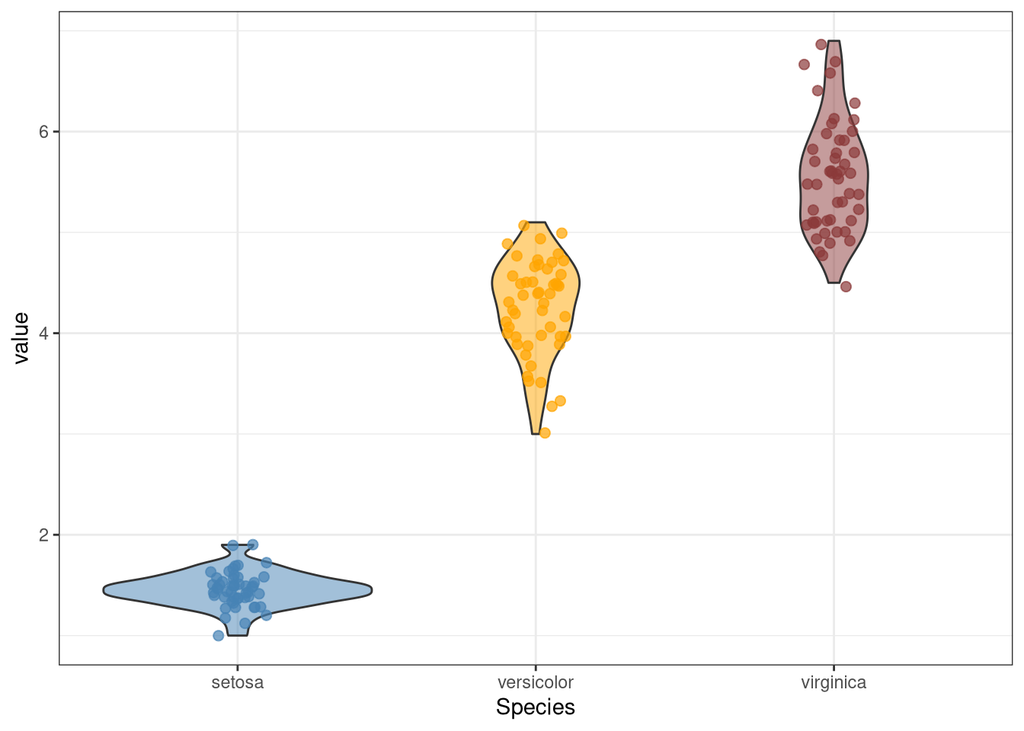

```r
iris_nest$plots[[3]]
```

### A test for each variable

Are the values measured in the three species different? We add a column with the outcome of a Kruskal-Wallis test of `value` against `Species` and then we extract the p-values

```r
iris_nest <- iris_nest |>
  mutate(kw = map(data, \(t) kruskal.test(value ~ Species, data = t)),
         p = map_dbl(kw, \(k) k$p.value))

iris_nest
```

```
## # A tibble: 4 × 5
##   variable     data               plots      kw             p
##   <chr>        <list>             <list>     <list>     <dbl>
## 1 Sepal.Length <tibble [150 × 3]> <ggplt2::> <htest> 8.92e-22
## 2 Sepal.Width  <tibble [150 × 3]> <ggplt2::> <htest> 1.57e-14
## 3 Petal.Length <tibble [150 × 3]> <ggplt2::> <htest> 4.80e-29
## 4 Petal.Width  <tibble [150 × 3]> <ggplt2::> <htest> 3.26e-29
```

All this can be condensed in a single pipe …

```r
iris_long |>
  nest(data = -variable) |>
  mutate(plots = map(data, my_plot),
         kw = map(data, \(t) kruskal.test(value ~ Species, data = t)),
         p = map_dbl(kw, \(k) k$p.value))
```

```
## # A tibble: 4 × 5
##   variable     data               plots      kw             p
##   <chr>        <list>             <list>     <list>     <dbl>
## 1 Sepal.Length <tibble [150 × 3]> <ggplt2::> <htest> 8.92e-22
## 2 Sepal.Width  <tibble [150 × 3]> <ggplt2::> <htest> 1.57e-14
## 3 Petal.Length <tibble [150 × 3]> <ggplt2::> <htest> 4.80e-29
## 4 Petal.Width  <tibble [150 × 3]> <ggplt2::> <htest> 3.26e-29
```

### Tidy model outputs with `broom`

Models (`lm`, `glm`, `nlme`, …) return outputs which are not super handy in a table context

```r
dummy_model <- lm(Petal.Width ~ Sepal.Width * Species, data = iris_tbl)

summary(dummy_model)
```

```
##
## Call:
## lm(formula = Petal.Width ~ Sepal.Width * Species, data = iris_tbl)
##
## Residuals:
##      Min       1Q   Median       3Q      Max
## -0.45473 -0.08236 -0.02478  0.09005  0.45368
##
## Coefficients:
##                               Estimate Std. Error t value Pr(>|t|)
## (Intercept)                    0.02418    0.22231   0.109 0.913542
## Sepal.Width                    0.06471    0.06447   1.004 0.317176
## Speciesversicolor              0.14273    0.31071   0.459 0.646666
## Speciesvirginica               0.63988    0.31747   2.016 0.045709 *
## Sepal.Width:Speciesversicolor  0.35374    0.10110   3.499 0.000622 ***
## Sepal.Width:Speciesvirginica   0.39324    0.09949   3.953 0.000121 ***
## ---
## Signif. codes:  0 '***' 0.001 '**' 0.01 '*' 0.05 '.' 0.1 ' ' 1
##
## Residual standard error: 0.1711 on 144 degrees of freedom
## Multiple R-squared:  0.9513, Adjusted R-squared:  0.9496
## F-statistic: 562.9 on 5 and 144 DF,  p-value: < 2.2e-16
```

Very informative, but in a pipeline it is better to have the coefficients and their p-values in a tibble. The `tidy()` function of the `broom` package does exactly that

```r
library(broom)

tidy(dummy_model)
```

```
## # A tibble: 6 × 5
##   term                          estimate std.error statistic  p.value
##   <chr>                            <dbl>     <dbl>     <dbl>    <dbl>
## 1 (Intercept)                     0.0242    0.222      0.109 0.914
## 2 Sepal.Width                     0.0647    0.0645     1.00  0.317
## 3 Speciesversicolor               0.143     0.311      0.459 0.647
## 4 Speciesvirginica                0.640     0.317      2.02  0.0457
## 5 Sepal.Width:Speciesversicolor   0.354     0.101      3.50  0.000622
## 6 Sepal.Width:Speciesvirginica    0.393     0.0995     3.95  0.000121
```

### Now for you

We used the Kruskal-Wallis test to check the dependence of each variable on the species.

Could you check if Sepal Length, Petal Length and Petal Width are associated with Sepal Width? Fit a linear model with Sepal Width as predictor and each of the other measures as response (if you are brave, also add the Species as a categorical predictor and check its interaction with Sepal Width).

### A possible solution

```r
iris_tbl |>
  pivot_longer(-c(Sepal.Width, Species), names_to = "variable", values_to = "value") |>
  nest(data = -variable) |>
  mutate(models = map(data, \(t) lm(value ~ Sepal.Width * Species, data = t)),
         terms = map(models, tidy)) |>
  unnest(terms) |>
  filter(p.value < 0.05) |>
  select(variable, term, estimate, std.error, p.value) |>
  arrange(desc(estimate))
```

```
## # A tibble: 9 × 5
##   variable     term                          estimate std.error    p.value
##   <chr>        <chr>                            <dbl>     <dbl>      <dbl>
## 1 Sepal.Length (Intercept)                      2.64     0.572  0.00000853
## 2 Petal.Length Speciesvirginica                 2.33     0.715  0.00141
## 3 Petal.Length (Intercept)                      1.18     0.501  0.0195
## 4 Petal.Length Sepal.Width:Speciesversicolor    0.758    0.228  0.00111
## 5 Sepal.Length Sepal.Width                      0.690    0.166  0.0000531
## 6 Petal.Width  Speciesvirginica                 0.640    0.317  0.0457
## 7 Petal.Length Sepal.Width:Speciesvirginica     0.605    0.224  0.00778
## 8 Petal.Width  Sepal.Width:Speciesvirginica     0.393    0.0995 0.000121
## 9 Petal.Width  Sepal.Width:Speciesversicolor    0.354    0.101  0.000622
```

## Homework: the central limit theorem

1. Create a tibble that contains 1000 independent samplings (of 50 values each) from a non normal distribution (I suggest the uniform or the lognormal distribution).
2. Show that the means of the samplings follow a normal distribution, regardless of the shape of the distribution we are drawing from.

To draw from different distributions:

- `runif()` for the uniform distribution
- `rlnorm()` for the lognormal distribution

This is a brute force demonstration of the **central limit theorem**.

### A possible solution

What we need: a tibble to store the data, with one row for each sampling …

```r
my_samplings <- tibble(id = 1:1000)
```

then we perform the actual sampling, storing each sample of 50 values in a list column …

```r
my_samplings <- my_samplings |>
  mutate(sampling = map(id, \(x) runif(50)))

my_samplings
```

```
## # A tibble: 1,000 × 2
##       id sampling
##    <int> <list>
##  1     1 <dbl [50]>
##  2     2 <dbl [50]>
##  3     3 <dbl [50]>
##  4     4 <dbl [50]>
##  5     5 <dbl [50]>
##  6     6 <dbl [50]>
##  7     7 <dbl [50]>
##  8     8 <dbl [50]>
##  9     9 <dbl [50]>
## 10    10 <dbl [50]>
## # ℹ 990 more rows
```

then we need a column with the mean of each sampling

```r
my_samplings <- my_samplings |>
  mutate(avg = map_dbl(sampling, mean))
```

and finally we look at the distribution of the means

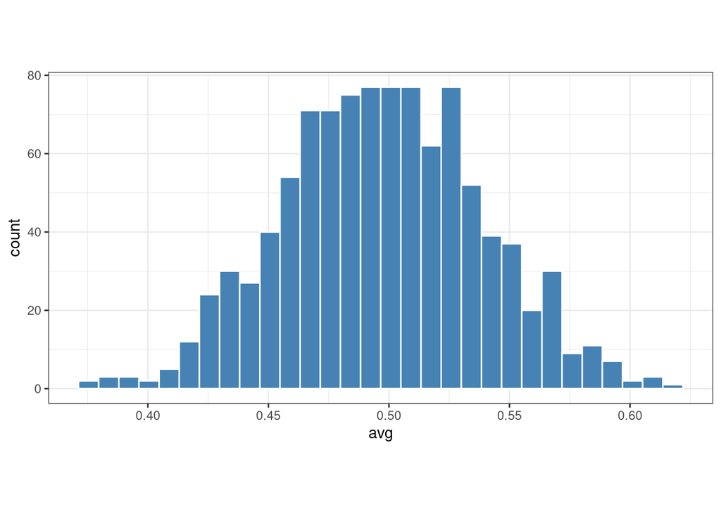

```r
my_samplings |>
  ggplot() +
  geom_histogram(aes(x = avg), fill = "steelblue", col = "white", bins = 30) +
  theme_bw() +
  theme(aspect.ratio = 0.5)
```

Even if the samplings are coming from a uniform distribution, their means are normally distributed.

### Let’s make it more nice …

The full process can be written as a single pipe. Here we also compare the two distributions, and we look at the shape of the data we are sampling from (left) and at the distribution of the means (right).

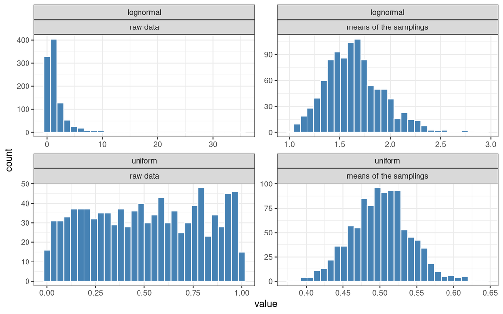

```r
samplings <- tibble(distribution = c("uniform", "lognormal")) |>
  mutate(draw = list(\(n) runif(n), \(n) rlnorm(n))) |>              ## the sampling functions
  mutate(sampling = map(draw, \(f) map(1:1000, \(i) f(50)))) |>      ## 1000 samplings of 50 values
  unnest(sampling) |>                                               ## one row for each sampling
  mutate(avg = map_dbl(sampling, mean))                             ## the means

## the raw values of the first 20 samplings of each distribution ...
raw_data <- samplings |>
  slice_head(n = 20, by = distribution) |>
  unnest(sampling) |>
  transmute(distribution, what = "raw data", value = sampling)

## ... and the means
means <- samplings |>
  transmute(distribution, what = "means of the samplings", value = avg)

bind_rows(raw_data, means) |>
  mutate(what = fct_inorder(what)) |>
  ggplot() +
  geom_histogram(aes(x = value), fill = "steelblue", col = "white", bins = 30) +
  facet_wrap(distribution ~ what, scales = "free") +
  theme_bw()
```

Look carefully at the lognormal case: the means are close to normal, but still a bit skewed to the right. The central limit theorem holds “for large samples”, and the more asymmetric the original distribution, the larger the sample needed to get a really normal distribution of the means. Many metabolite concentrations are lognormal-like, so keep this in mind when you have few samples!

**Try it yourself**: change the size of each sampling from 50 to 5 and to 500, and look at what happens to the distribution of the means.